# Münster traffic data, *Shiny*

Thomas Kluth, Thorben Jensen

R Meetup 2018-06-11

# “I’m here for the drinks. What *is* Shiny, though?”

“Shiny is an R package that makes it easy to  
**build interactive web apps straight from R**  
…  
Shiny combines the computational **power of R**  
with the **interactivity** of the modern web.”  
- shiny.rstudio.com

## Shiny = R + visualization + interaction

# why we love Shiny and why you should, too

## R centered

- Get started with 20 lines of code
- Best web tool for R coders
- Well integrated with RStudio

## Quickly developed

- First app in 15 minutes
- Rapid prototyping
- No HTML, Javascript, PHP, Flash, …

## Shiny

- Good looks by default
- Styleable with CSS
- Extendable (e.g. d3)

# how Shiny works

## Typical Workflow

1. Model & visualize, e.g. `ggplot2`
2. Include in Shiny, including interactiveness
3. App done!

## Parts of shiny app

```
library(shiny)

...  # LOAD DATA

ui <- ...  # FRONTEND

server <- ...  # BACKEND

shinyApp(ui = ui, server = server)  # START APP
```

## Demo!

`https://github.com/ThorbenJensen/garage-shiny`

## Part 1/4: load data

```
df_processed <-
  df %>%
  mutate(., free = as.numeric(free)) %>%
  mutate(., datetime = as_datetime(df$datetime,
                                   tz = "Europe/Berlin")) %>%
  mutate(., time = hms::as.hms(datetime))
```

## Part 2/4: frontend

```
ui <- fluidPage(

  titlePanel("Need a parking spot ?"),

  sidebarLayout(
    sidebarPanel(
      selectInput(inputId = "garage_name",
                  label = "Choose a car park:",
                  choices = unique(df_processed$name),
                  selected = "Parkhaus Karstadt")
    ),
    mainPanel(
      plotOutput(outputId = "time_series_plot")
    )
  ),
  theme = "custom.css"
)
```

## Part 3/4: CSS

```
@import url('https://fonts.googleapis.com/css?family=Satisfy');

.h2, h2 {
  font-size: 60px;
  font-family: 'Satisfy', courier;
  color: #f14559;
}

body {
  font-size: 20px;
}

.well {
  background-color: #f13a5994;
}
```

## Part 4/4: backend

```
server <- function(input, output) {

  output$time_series_plot <- renderPlot({

    df_processed %>%
      filter(., name == input$garage_name) %>%
      ggplot(data = ., aes(x = time, y = free)) +
      geom_line(aes(group = date), alpha = .3) +
      theme_bw() +
      xlab("Time of day") +
      ylab("Free spots") +
      ggtitle(paste0("Free parking spots per day for car park '",
                     input$garage_name, "'")) +
      theme(text = element_text(size = 20))
  })
}
```

## Containerize it!

why? makes shiny easily deployable!

1. Write Dockerfile

   ```
   FROM rocker/shiny
   RUN install2.r --error dplyr lubridate ggplot2 hms
   COPY ./app /srv/shiny-server/
   ```

2. Build and run container

   ```
   docker build -t garage-shiny .
   docker run --rm -p 3838:3838 garage-shiny
   ```

# our project Traffic Dynamics

## Why Traffic Data? Climate Change!

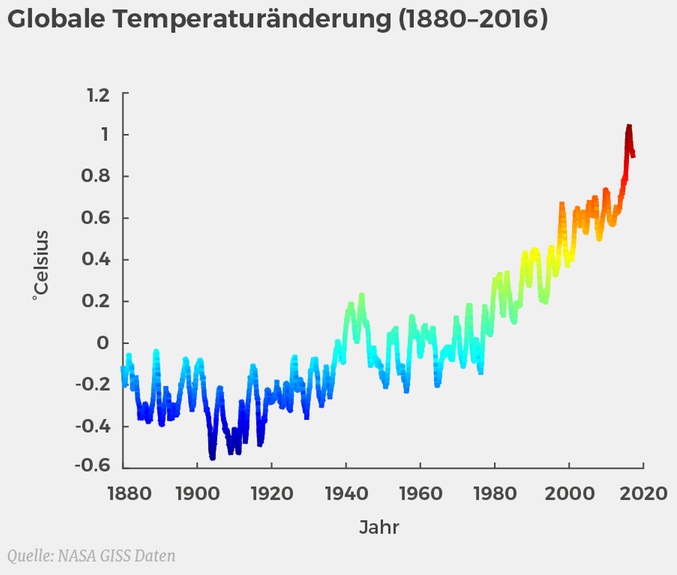

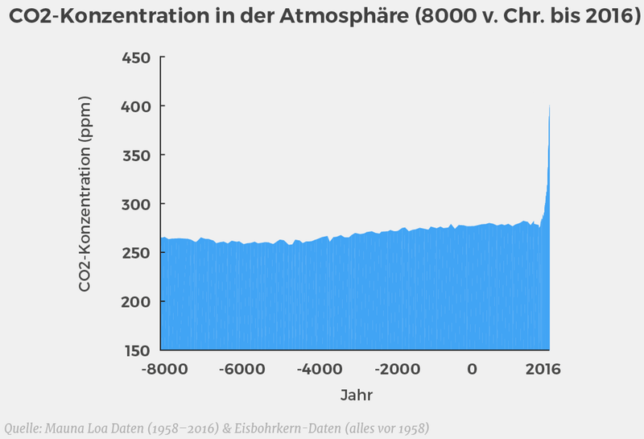

## Emissions

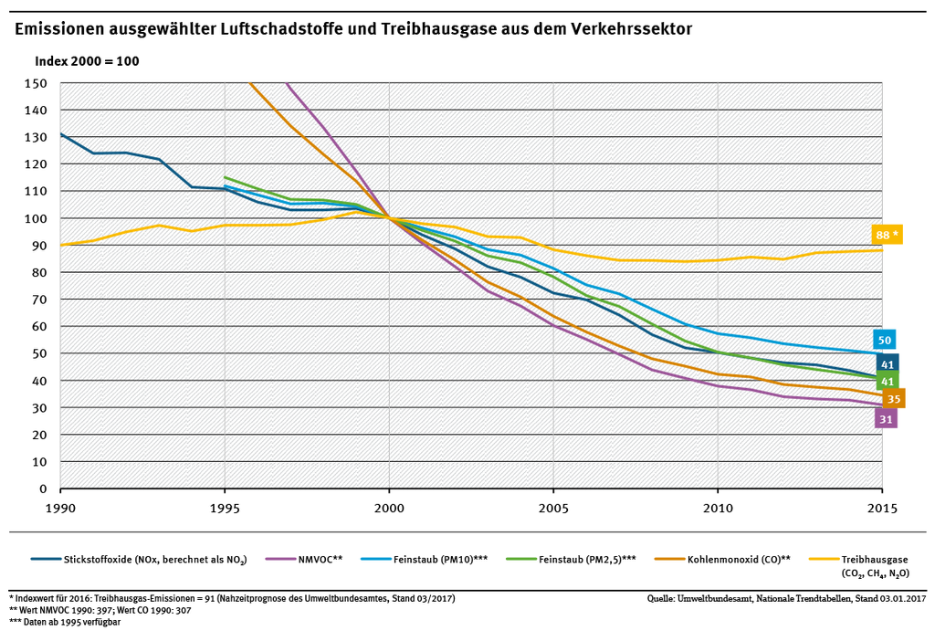

## Kilometers

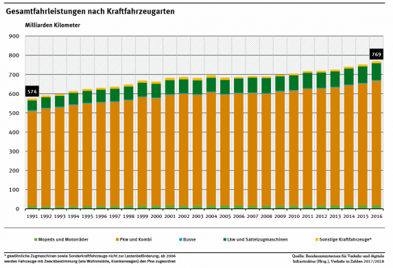

## Open Data

- hourly traffic counts & weather conditions
- data source: Stadt Münster, open data license

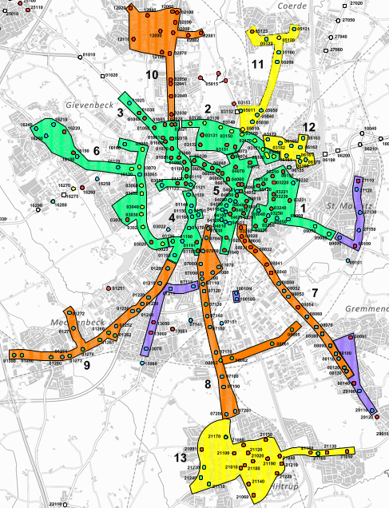

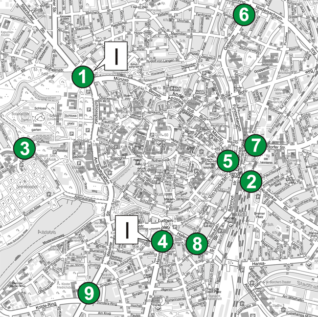

## Demo!

`https://traffics.codeformuenster.org`

# Showdown: Bayesian regression models in Shiny

## Example question to the data

- Does the weather affect the number of cyclists? How?

```
library(brms)

bike_model <- brm(count ~ temperature + windspeed + rain + month,
                  family = negbinomial,
                  data = bikes_neutor)
```

## How to include in Shiny

- `ui`

```
...
plotlyOutput("plotTemperature"),
...
```

- `server`

```
  output$plotTemperature <- renderPlotly({
    p <- plot(marginal_effects(bike_model,
                       effects = "temperature",
                       plot = FALSE)
              )[[1]] +
         xlab("Temperatur (in °C)") +
         ylab("Anzahl Fahrräder") +
         theme_minimal()

    ggplotly(p)
  })
```

## Demo!

`https://traffics.codeformuenster.org`

# your turn: what else to analyze?

## Our questions to you

- What would you like to know about traffic data?
- Any ideas for analyses/models?
- Do you know stakeholders to involve?

# our turn: more questions?

## contact us

- t.kluth @ posteo.de
- jensen.thorben @ gmail.com

## Thanks to

- Tobias Bradtke, Code for Münster
- Ralf Renkhoff, Stadt Münster
- IG Fahrradstadt

## Thank you!

## Sources

- climate change graphics: https://perspective-daily.de/article/391/SjcGXmvB
- emissions graphics: https://www.umweltbundesamt.de/daten/verkehr/umweltbelastungen-durch-verkehr#textpart-3
- kilometers graphics: https://www.umweltbundesamt.de/daten/verkehr/fahrleistungen-verkehrsaufwand-modal-split#textpart-1
- bike counter map: https://www.stadt-muenster.de/verkehrsplanung/verkehr-in-zahlen/radverkehrszaehlungen.html